# T-test

Emrah Kırdök, Ph. D.

4/6/2022

# 1 Giriş

Bu döküman kapsamında R üzerinde t-test ile ile ilgili bilgiler verilecektir.

## 1.1 t.test()

Tanım olarak t-testi, iki grubun ortamaları arasında anlamlı bir fark olup olmadığını test etmek için kulanılabilir.

Bunu göstermek için iki farklı dağlım simüle edelim.

```r
dagilim1 <- rnorm(n = 1000, mean = 2, sd = 1)
dagilim2 <- rnorm(n = 1000, mean = 5, sd = 1)
```

Histogramlar ile bu dağılımları inceleyelim:

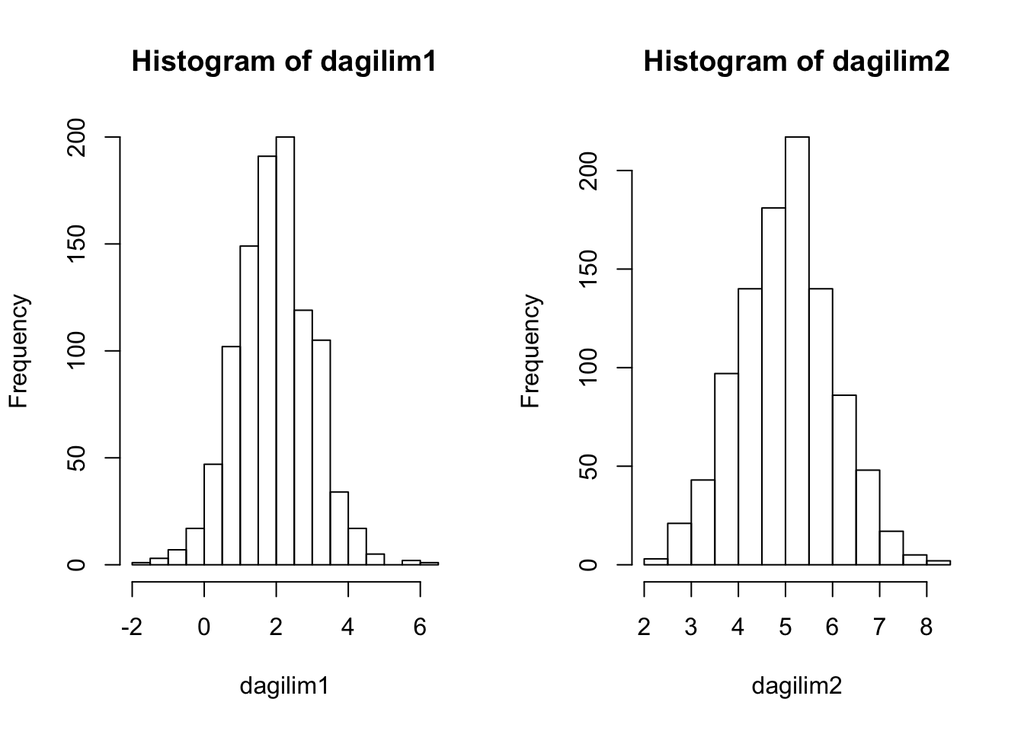

```r
par(mfrow=c(1,2))
hist(dagilim1)
hist(dagilim2)
```

İstersek yoğunluk grafiğiyle de bunu görselleştirebiliriz. Burada iki dağımı alıp, bir veri çerçevesinin içersine yerleştirdik, ve dagilim1 ve dagilim2 olarak iki farklı faktör verisi oluşturduk:

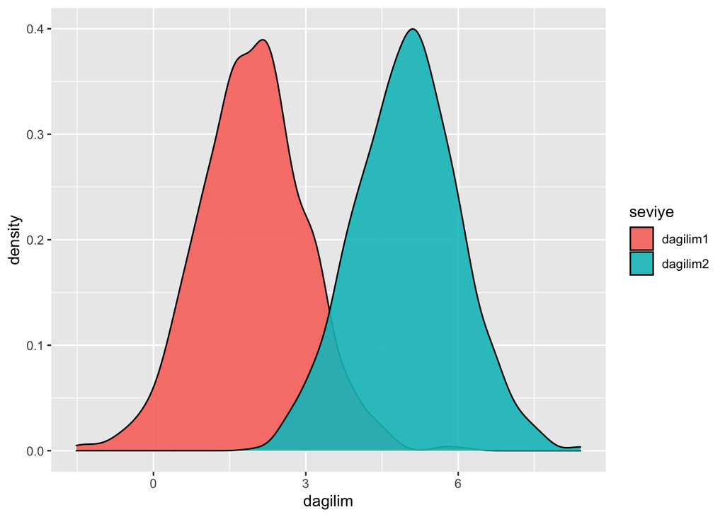

```r
sim <- data.frame(
  dagilim = c(dagilim1, dagilim2),
  seviye = c(
    rep("dagilim1", 1000),
    rep("dagilim2", 1000)
    )
  )

library(ggplot2)
ggplot(data = sim, aes(x=dagilim)) + geom_density(aes(fill = seviye), alpha = 0.9)
```

Dikkat ederseniz bu iki dağılımın ortalamarı birbirlerinden farklı. Peki bu fark anlamlı mı? Bunu tespit etmek için `t.test` kullanabiliriz:

```r
test <- t.test(x = dagilim1, y = dagilim2)

test
```

```
##
##  Welch Two Sample t-test
##
## data:  dagilim1 and dagilim2
## t = -66.559, df = 1996.2, p-value < 2.2e-16
## alternative hypothesis: true difference in means is not equal to 0
## 95 percent confidence interval:
##  -3.133606 -2.954230
## sample estimates:
## mean of x mean of y
##  1.951181  4.995099
```

Burada dikkat etmemiz gereken iki nokta var:

- mean of x, mean of y satırı
- p-value

P value bizim için önemli bir değer. T testi sonunda elde ettiğimiz p-değerini şu şekilde geri döndürebiliriz:

```r
test$p.value
```

```
## [1] 0
```

Dikkat ederseniz bu değer çok düşük. Bu sonuç aslında, bu iki dağılımın ortalamalarının birbirlerinden farklı olduğunu gösteriyor bize.

## 1.2 Hipotez testi

Bu kısım biraz kafa karıştırıcı. Eğer ilk dersleri hatırlarsanız, bilimde bir şeyi doğrudan kanıtlayamadığımızı hatırlarsınız. bu nedenle bir hipotezi doğrudan kanıtlama imkanımız yoktur. Bir hipotezi, ancak onun karşıtını reddederek *kabul edebiliriz*.

Nasıl mı? Bir önceki örnekte iki dağılımın birbirinden farklı olduğu hipotezini ortaya atmıştık. Bu mantığa göre, bu hipotezi test etmenin yolu, bu hipotezin zıddını test etmekten geçer.

Yani aslında ortaya iki tane hipotez atıyoruz:

- H0 (sıfır hipotezi): Bu iki dağılımın ortamaları birbirine eşittir
- HA (alternatif hipotez): Bu iki dağılımın ortalamarı birbirinden farklıdır

Yapmaya çalıştığımız ise doğrudan sıfır hipotezini reddedmeye çalışmak. Bu sayede alternatif hipotezi kabul edebiliriz.

Testimiz sonucunda bir p-değeri elde etmiştik hatırlarsınız. Bu p-değeri işte, sıfır hipotezinin oluşma olasılığını ifade etmekte. Bizim elde ettiğimiz p-değeri neydi?

```r
test$p.value
```

```
## [1] 0
```

Bu değer çok çok çok düşük bir değer. Yani bu iki dağılımın ortalamalarının aynı olması çok düşük bir olasılık. Bu olasılığın anlamlı olup olmadığını öğrenmek için ise belirli $alpha$ değerleri kullanılır:

- 0.001 (binde 1 hata olasılığı)
- 0.01 (%1 hata olasılığı)
- 0.05 (%5 hata olasığı)

```r
test$p.value < 0.001
```

```
## [1] TRUE
```

Şimdi tekrar örneğimize geri dönelim:

```r
test
```

```
##
##  Welch Two Sample t-test
##
## data:  dagilim1 and dagilim2
## t = -66.559, df = 1996.2, p-value < 2.2e-16
## alternative hypothesis: true difference in means is not equal to 0
## 95 percent confidence interval:
##  -3.133606 -2.954230
## sample estimates:
## mean of x mean of y
##  1.951181  4.995099
```

Şu satıra bakalım:

- alternative hypothesis: true difference in means is not equal to 0

## 1.3 İkinci bir örnek

Şimdi ise, birbirine çok benzer iki dağılım simüle edelim:

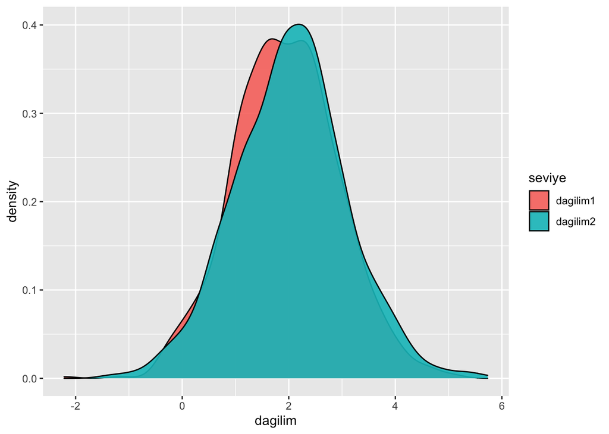

```r
dagilim1 <- rnorm(n = 1000, mean = 2, sd = 1)
dagilim2 <- rnorm(n = 1000, mean = 2, sd = 1)

sim <- data.frame(
  dagilim = c(dagilim1, dagilim2),
  seviye = c(
    rep("dagilim1", 1000),
    rep("dagilim2", 1000)
    )
  )

library(ggplot2)

ggplot(data = sim, aes(x=dagilim)) + geom_density(aes(fill = seviye), alpha = 0.9)
```

Dikkat ederseniz, bu dağılımların ortalamalrı üst üste bindi. Peki t-testi uygularsak nasıl bir sonuç elde edeceğiz?

```r
test <- t.test(x = dagilim1, y = dagilim2)

test
```

```
##
##  Welch Two Sample t-test
##
## data:  dagilim1 and dagilim2
## t = -1.9993, df = 1988.9, p-value = 0.04572
## alternative hypothesis: true difference in means is not equal to 0
## 95 percent confidence interval:
##  -0.179199524 -0.001723607
## sample estimates:
## mean of x mean of y
##  1.945295  2.035756
```

Bu sonuçta bakmamız gereken şey aslında şu: Bu iki dağılımın ortalamaları çok az da olsa birbirlerinden farklı. Peki bu farklılık anlamlı mı?

```r
test$p.value< 0.001
```

```
## [1] FALSE
```

## 1.4 Iris veri seti ile çalışma

Şimdi ise `iris` veri seti ile çalışalım.

Petal uzunluklarına bakabilir miyiz yine?

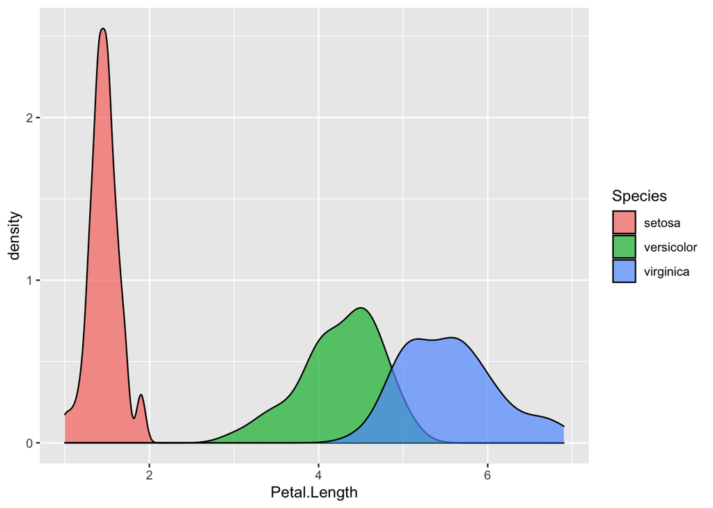

```r
ggplot(data = iris, aes(x = Petal.Length)) + geom_density(aes(fill = Species), alpha = 0.7)
```

Acaba, *versicolor* ve *virginica* türlerinin petal uzunlukları birbirlerinden anlamlı olarak farklı mı ($alpha$ değerini 0.05 alınız)?

Öncelikle sadece *versicolor* ve *virginica* türlerine ait petal uzunluklarının olduğu iki farklı vektör oluşturmalıyız:

```r
versicolor_petal_length  <- iris$Petal.Length[iris$Species == "versicolor"]
virginica_petal_length  <- iris$Petal.Length[iris$Species == "virginica"]
```

Şimdi t testini uygulayalım:

```r
test <- t.test(x = versicolor_petal_length, y = virginica_petal_length)
```

Sonuçları inceleyelim:

```r
test
```

```
##
##  Welch Two Sample t-test
##
## data:  versicolor_petal_length and virginica_petal_length
## t = -12.604, df = 95.57, p-value < 2.2e-16
## alternative hypothesis: true difference in means is not equal to 0
## 95 percent confidence interval:
##  -1.49549 -1.08851
## sample estimates:
## mean of x mean of y
##     4.260     5.552
```

Peki sonuç anlamlı mı?

```r
test$p.value < 0.05
```

```
## [1] TRUE
```

Evet, *versicolor* ve *virginica* türlerinin petal uzunlukları birbirlerinden anlamlı olarak farklı!